# ExtraTreesClassifier

**class*sklearn.ensemble.ExtraTreesClassifier(*n_estimators=100*, *, *criterion='gini'*, *max_depth=None*, *min_samples_split=2*, *min_samples_leaf=1*, *min_weight_fraction_leaf=0.0*, *max_features='sqrt'*, *max_leaf_nodes=None*, *min_impurity_decrease=0.0*, *bootstrap=False*, *oob_score=False*, *n_jobs=None*, *random_state=None*, *verbose=0*, *warm_start=False*, *class_weight=None*, *ccp_alpha=0.0*, *max_samples=None*, *monotonic_cst=None*)[[source]](https://github.com/scikit-learn/scikit-learn/blob/99bf3d8e4/sklearn/ensemble/_forest.py#L1923)**

An extra-trees classifier.

This class implements a meta estimator that fits a number of randomized decision trees (a.k.a. extra-trees) on various sub-samples of the dataset and uses averaging to improve the predictive accuracy and control over-fitting.

Read more in the User Guide.

**Parameters:**

**n_estimators**int, default=100**

The number of trees in the forest.

Changed in version 0.22: The default value of `n_estimators` changed from 10 to 100 in 0.22.

**criterion**{“gini”, “entropy”, “log_loss”}, default=”gini”**

The function to measure the quality of a split. Supported criteria are “gini” for the Gini impurity and “log_loss” and “entropy” both for the Shannon information gain, see Mathematical formulation. Note: This parameter is tree-specific.

**max_depth**int, default=None**

The maximum depth of the tree. If None, then nodes are expanded until all leaves are pure or until all leaves contain less than min_samples_split samples.

**min_samples_split**int or float, default=2**

The minimum number of samples required to split an internal node:

- If int, then consider `min_samples_split` as the minimum number.
- If float, then `min_samples_split` is a fraction and `ceil(min_samples_split * n_samples)` are the minimum number of samples for each split.

Changed in version 0.18: Added float values for fractions.

**min_samples_leaf**int or float, default=1**

The minimum number of samples required to be at a leaf node. A split point at any depth will only be considered if it leaves at least `min_samples_leaf` training samples in each of the left and right branches. This may have the effect of smoothing the model, especially in regression.

- If int, then consider `min_samples_leaf` as the minimum number.
- If float, then `min_samples_leaf` is a fraction and `ceil(min_samples_leaf * n_samples)` are the minimum number of samples for each node.

Changed in version 0.18: Added float values for fractions.

**min_weight_fraction_leaf**float, default=0.0**

The minimum weighted fraction of the sum total of weights (of all the input samples) required to be at a leaf node. Samples have equal weight when sample_weight is not provided.

**max_features**{“sqrt”, “log2”, None}, int or float, default=”sqrt”**

The number of features to consider when looking for the best split:

- If int, then consider `max_features` features at each split.
- If float, then `max_features` is a fraction and `max(1, int(max_features * n_features_in_))` features are considered at each split.
- If “sqrt”, then `max_features=sqrt(n_features)`.
- If “log2”, then `max_features=log2(n_features)`.
- If None, then `max_features=n_features`.

Changed in version 1.1: The default of `max_features` changed from `"auto"` to `"sqrt"`.

Note: the search for a split does not stop until at least one valid partition of the node samples is found, even if it requires to effectively inspect more than `max_features` features.

**max_leaf_nodes**int, default=None**

Grow trees with `max_leaf_nodes` in best-first fashion. Best nodes are defined as relative reduction in impurity. If None then unlimited number of leaf nodes.

**min_impurity_decrease**float, default=0.0**

A node will be split if this split induces a decrease of the impurity greater than or equal to this value.

The weighted impurity decrease equation is the following:

```
N_t / N * (impurity - N_t_R / N_t * right_impurity
                    - N_t_L / N_t * left_impurity)
```

where `N` is the total number of samples, `N_t` is the number of samples at the current node, `N_t_L` is the number of samples in the left child, and `N_t_R` is the number of samples in the right child.

`N`, `N_t`, `N_t_R` and `N_t_L` all refer to the weighted sum, if `sample_weight` is passed.

Added in version 0.19.

**bootstrap**bool, default=False**

Whether bootstrap samples are used when building trees. If False, the whole dataset is used to build each tree.

**oob_score**bool or callable, default=False**

Whether to use out-of-bag samples to estimate the generalization score. By default, `accuracy_score` is used. Provide a callable with signature `metric(y_true, y_pred)` to use a custom metric. Only available if `bootstrap=True`.

**n_jobs**int, default=None**

The number of jobs to run in parallel. `fit`, `predict`, `decision_path` and `apply` are all parallelized over the trees. `None` means 1 unless in a [`joblib.parallel_backend`](https://joblib.readthedocs.io/en/latest/generated/joblib.parallel_backend.html#joblib.parallel_backend) context. `-1` means using all processors. See [Glossary](https://scikit-learn.org/1.6/glossary.html#term-n_jobs) for more details.

**random_state**int, RandomState instance or None, default=None**

Controls 3 sources of randomness:

- the bootstrapping of the samples used when building trees (if `bootstrap=True`)
- the sampling of the features to consider when looking for the best split at each node (if `max_features < n_features`)
- the draw of the splits for each of the `max_features`

See [Glossary](https://scikit-learn.org/1.6/glossary.html#term-random_state) for details.

**verbose**int, default=0**

Controls the verbosity when fitting and predicting.

**warm_start**bool, default=False**

When set to `True`, reuse the solution of the previous call to fit and add more estimators to the ensemble, otherwise, just fit a whole new forest. See [Glossary](https://scikit-learn.org/1.6/glossary.html#term-warm_start) and Fitting additional trees for details.

**class_weight**{“balanced”, “balanced_subsample”}, dict or list of dicts, default=None**

Weights associated with classes in the form `{class_label: weight}`. If not given, all classes are supposed to have weight one. For multi-output problems, a list of dicts can be provided in the same order as the columns of y.

Note that for multioutput (including multilabel) weights should be defined for each class of every column in its own dict. For example, for four-class multilabel classification weights should be [{0: 1, 1: 1}, {0: 1, 1: 5}, {0: 1, 1: 1}, {0: 1, 1: 1}] instead of [{1:1}, {2:5}, {3:1}, {4:1}].

The “balanced” mode uses the values of y to automatically adjust weights inversely proportional to class frequencies in the input data as `n_samples / (n_classes * np.bincount(y))`

The “balanced_subsample” mode is the same as “balanced” except that weights are computed based on the bootstrap sample for every tree grown.

For multi-output, the weights of each column of y will be multiplied.

Note that these weights will be multiplied with sample_weight (passed through the fit method) if sample_weight is specified.

**ccp_alpha**non-negative float, default=0.0**

Complexity parameter used for Minimal Cost-Complexity Pruning. The subtree with the largest cost complexity that is smaller than `ccp_alpha` will be chosen. By default, no pruning is performed. See Minimal Cost-Complexity Pruning for details. See Post pruning decision trees with cost complexity pruning for an example of such pruning.

Added in version 0.22.

**max_samples**int or float, default=None**

If bootstrap is True, the number of samples to draw from X to train each base estimator.

- If None (default), then draw `X.shape[0]` samples.
- If int, then draw `max_samples` samples.
- If float, then draw `max_samples * X.shape[0]` samples. Thus, `max_samples` should be in the interval `(0.0, 1.0]`.

Added in version 0.22.

**monotonic_cst**array-like of int of shape (n_features), default=None**

**Indicates the monotonicity constraint to enforce on each feature.**

- 1: monotonically increasing
- 0: no constraint
- -1: monotonically decreasing

If monotonic_cst is None, no constraints are applied.

**Monotonicity constraints are not supported for:**

- multiclass classifications (i.e. when `n_classes > 2`),
- multioutput classifications (i.e. when `n_outputs_ > 1`),
- classifications trained on data with missing values.

The constraints hold over the probability of the positive class.

Read more in the User Guide.

Added in version 1.4.

**Attributes:**

**estimator_**`ExtraTreeClassifier`**

The child estimator template used to create the collection of fitted sub-estimators.

Added in version 1.2: `base_estimator_` was renamed to `estimator_`.

**estimators_**list of DecisionTreeClassifier**

The collection of fitted sub-estimators.

**classes_**ndarray of shape (n_classes,) or a list of such arrays**

The classes labels (single output problem), or a list of arrays of class labels (multi-output problem).

**n_classes_**int or list**

The number of classes (single output problem), or a list containing the number of classes for each output (multi-output problem).

**`feature_importances_`ndarray of shape (n_features,)**

The impurity-based feature importances.

**n_features_in_**int**

Number of features seen during fit.

Added in version 0.24.

**feature_names_in_**ndarray of shape (`n_features_in_`,)**

Names of features seen during fit. Defined only when `X` has feature names that are all strings.

Added in version 1.0.

**n_outputs_**int**

The number of outputs when `fit` is performed.

**oob_score_**float**

Score of the training dataset obtained using an out-of-bag estimate. This attribute exists only when `oob_score` is True.

**oob_decision_function_**ndarray of shape (n_samples, n_classes) or (n_samples, n_classes, n_outputs)**

Decision function computed with out-of-bag estimate on the training set. If n_estimators is small it might be possible that a data point was never left out during the bootstrap. In this case, `oob_decision_function_` might contain NaN. This attribute exists only when `oob_score` is True.

**`estimators_samples_`list of arrays**

The subset of drawn samples for each base estimator.

See also

**`ExtraTreesRegressor`**

An extra-trees regressor with random splits.

**`RandomForestClassifier`**

A random forest classifier with optimal splits.

**`RandomForestRegressor`**

Ensemble regressor using trees with optimal splits.

#### Notes

The default values for the parameters controlling the size of the trees (e.g. `max_depth`, `min_samples_leaf`, etc.) lead to fully grown and unpruned trees which can potentially be very large on some data sets. To reduce memory consumption, the complexity and size of the trees should be controlled by setting those parameter values.

#### References

[1]

P. Geurts, D. Ernst., and L. Wehenkel, “Extremely randomized trees”, Machine Learning, 63(1), 3-42, 2006.

#### Examples

```
>>> from sklearn.ensemble import ExtraTreesClassifier
>>> from sklearn.datasets import make_classification
>>> X, y = make_classification(n_features=4, random_state=0)
>>> clf = ExtraTreesClassifier(n_estimators=100, random_state=0)
>>> clf.fit(X, y)
ExtraTreesClassifier(random_state=0)
>>> clf.predict([[0, 0, 0, 0]])
array([1])
```

**apply(*X*)[[source]](https://github.com/scikit-learn/scikit-learn/blob/99bf3d8e4/sklearn/ensemble/_forest.py#L262)**

Apply trees in the forest to X, return leaf indices.

**Parameters:**

**X**{array-like, sparse matrix} of shape (n_samples, n_features)**

The input samples. Internally, its dtype will be converted to `dtype=np.float32`. If a sparse matrix is provided, it will be converted into a sparse `csr_matrix`.

**Returns:**

**X_leaves**ndarray of shape (n_samples, n_estimators)**

For each datapoint x in X and for each tree in the forest, return the index of the leaf x ends up in.

**decision_path(*X*)[[source]](https://github.com/scikit-learn/scikit-learn/blob/99bf3d8e4/sklearn/ensemble/_forest.py#L288)**

Return the decision path in the forest.

Added in version 0.18.

**Parameters:**

**X**{array-like, sparse matrix} of shape (n_samples, n_features)**

The input samples. Internally, its dtype will be converted to `dtype=np.float32`. If a sparse matrix is provided, it will be converted into a sparse `csr_matrix`.

**Returns:**

**indicator**sparse matrix of shape (n_samples, n_nodes)**

Return a node indicator matrix where non zero elements indicates that the samples goes through the nodes. The matrix is of CSR format.

**n_nodes_ptr**ndarray of shape (n_estimators + 1,)**

The columns from indicator[n_nodes_ptr[i]:n_nodes_ptr[i+1]] gives the indicator value for the i-th estimator.

**property*estimators_samples_**

The subset of drawn samples for each base estimator.

Returns a dynamically generated list of indices identifying the samples used for fitting each member of the ensemble, i.e., the in-bag samples.

Note: the list is re-created at each call to the property in order to reduce the object memory footprint by not storing the sampling data. Thus fetching the property may be slower than expected.

**property*feature_importances_**

The impurity-based feature importances.

The higher, the more important the feature. The importance of a feature is computed as the (normalized) total reduction of the criterion brought by that feature. It is also known as the Gini importance.

Warning: impurity-based feature importances can be misleading for high cardinality features (many unique values). See `sklearn.inspection.permutation_importance` as an alternative.

**Returns:**

**feature_importances_**ndarray of shape (n_features,)**

The values of this array sum to 1, unless all trees are single node trees consisting of only the root node, in which case it will be an array of zeros.

**fit(*X*, *y*, *sample_weight=None*)[[source]](https://github.com/scikit-learn/scikit-learn/blob/99bf3d8e4/sklearn/ensemble/_forest.py#L328)**

Build a forest of trees from the training set (X, y).

**Parameters:**

**X**{array-like, sparse matrix} of shape (n_samples, n_features)**

The training input samples. Internally, its dtype will be converted to `dtype=np.float32`. If a sparse matrix is provided, it will be converted into a sparse `csc_matrix`.

**y**array-like of shape (n_samples,) or (n_samples, n_outputs)**

The target values (class labels in classification, real numbers in regression).

**sample_weight**array-like of shape (n_samples,), default=None**

Sample weights. If None, then samples are equally weighted. Splits that would create child nodes with net zero or negative weight are ignored while searching for a split in each node. In the case of classification, splits are also ignored if they would result in any single class carrying a negative weight in either child node.

**Returns:**

**self**object**

Fitted estimator.

**get_metadata_routing()[[source]](https://github.com/scikit-learn/scikit-learn/blob/99bf3d8e4/sklearn/utils/_metadata_requests.py#L1497)**

Get metadata routing of this object.

Please check [User Guide](https://scikit-learn.org/1.6/metadata_routing.html#metadata-routing) on how the routing mechanism works.

**Returns:**

**routing**MetadataRequest**

A `MetadataRequest` encapsulating routing information.

**get_params(*deep=True*)[[source]](https://github.com/scikit-learn/scikit-learn/blob/99bf3d8e4/sklearn/base.py#L231)**

Get parameters for this estimator.

**Parameters:**

**deep**bool, default=True**

If True, will return the parameters for this estimator and contained subobjects that are estimators.

**Returns:**

**params**dict**

Parameter names mapped to their values.

**predict(*X*)[[source]](https://github.com/scikit-learn/scikit-learn/blob/99bf3d8e4/sklearn/ensemble/_forest.py#L883)**

Predict class for X.

The predicted class of an input sample is a vote by the trees in the forest, weighted by their probability estimates. That is, the predicted class is the one with highest mean probability estimate across the trees.

**Parameters:**

**X**{array-like, sparse matrix} of shape (n_samples, n_features)**

The input samples. Internally, its dtype will be converted to `dtype=np.float32`. If a sparse matrix is provided, it will be converted into a sparse `csr_matrix`.

**Returns:**

**y**ndarray of shape (n_samples,) or (n_samples, n_outputs)**

The predicted classes.

**predict_log_proba(*X*)[[source]](https://github.com/scikit-learn/scikit-learn/blob/99bf3d8e4/sklearn/ensemble/_forest.py#L970)**

Predict class log-probabilities for X.

The predicted class log-probabilities of an input sample is computed as the log of the mean predicted class probabilities of the trees in the forest.

**Parameters:**

**X**{array-like, sparse matrix} of shape (n_samples, n_features)**

The input samples. Internally, its dtype will be converted to `dtype=np.float32`. If a sparse matrix is provided, it will be converted into a sparse `csr_matrix`.

**Returns:**

**p**ndarray of shape (n_samples, n_classes), or a list of such arrays**

The class probabilities of the input samples. The order of the classes corresponds to that in the attribute classes_.

**predict_proba(*X*)[[source]](https://github.com/scikit-learn/scikit-learn/blob/99bf3d8e4/sklearn/ensemble/_forest.py#L922)**

Predict class probabilities for X.

The predicted class probabilities of an input sample are computed as the mean predicted class probabilities of the trees in the forest. The class probability of a single tree is the fraction of samples of the same class in a leaf.

**Parameters:**

**X**{array-like, sparse matrix} of shape (n_samples, n_features)**

The input samples. Internally, its dtype will be converted to `dtype=np.float32`. If a sparse matrix is provided, it will be converted into a sparse `csr_matrix`.

**Returns:**

**p**ndarray of shape (n_samples, n_classes), or a list of such arrays**

The class probabilities of the input samples. The order of the classes corresponds to that in the attribute classes_.

**score(*X*, *y*, *sample_weight=None*)[[source]](https://github.com/scikit-learn/scikit-learn/blob/99bf3d8e4/sklearn/base.py#L546)**

Return the mean accuracy on the given test data and labels.

In multi-label classification, this is the subset accuracy which is a harsh metric since you require for each sample that each label set be correctly predicted.

**Parameters:**

**X**array-like of shape (n_samples, n_features)**

Test samples.

**y**array-like of shape (n_samples,) or (n_samples, n_outputs)**

True labels for `X`.

**sample_weight**array-like of shape (n_samples,), default=None**

Sample weights.

**Returns:**

**score**float**

Mean accuracy of `self.predict(X)` w.r.t. `y`.

**set_fit_request(*, *sample_weight:bool|None|str='$UNCHANGED$'*) → ExtraTreesClassifier[[source]](https://github.com/scikit-learn/scikit-learn/blob/99bf3d8e4/sklearn/utils/_metadata_requests.py#L1251)**

Request metadata passed to the `fit` method.

Note that this method is only relevant if `enable_metadata_routing=True` (see `sklearn.set_config`). Please see [User Guide](https://scikit-learn.org/1.6/metadata_routing.html#metadata-routing) on how the routing mechanism works.

The options for each parameter are:

- `True`: metadata is requested, and passed to `fit` if provided. The request is ignored if metadata is not provided.
- `False`: metadata is not requested and the meta-estimator will not pass it to `fit`.
- `None`: metadata is not requested, and the meta-estimator will raise an error if the user provides it.
- `str`: metadata should be passed to the meta-estimator with this given alias instead of the original name.

The default (`sklearn.utils.metadata_routing.UNCHANGED`) retains the existing request. This allows you to change the request for some parameters and not others.

Added in version 1.3.

Note

This method is only relevant if this estimator is used as a sub-estimator of a meta-estimator, e.g. used inside a `Pipeline`. Otherwise it has no effect.

**Parameters:**

**sample_weight**str, True, False, or None, default=sklearn.utils.metadata_routing.UNCHANGED**

Metadata routing for `sample_weight` parameter in `fit`.

**Returns:**

**self**object**

The updated object.

**set_params(**params)[[source]](https://github.com/scikit-learn/scikit-learn/blob/99bf3d8e4/sklearn/base.py#L255)**

Set the parameters of this estimator.

The method works on simple estimators as well as on nested objects (such as `Pipeline`). The latter have parameters of the form `<component>__<parameter>` so that it’s possible to update each component of a nested object.

**Parameters:**

**paramsdict**

Estimator parameters.

**Returns:**

**self**estimator instance**

Estimator instance.

**set_score_request(*, *sample_weight:bool|None|str='$UNCHANGED$'*) → ExtraTreesClassifier[[source]](https://github.com/scikit-learn/scikit-learn/blob/99bf3d8e4/sklearn/utils/_metadata_requests.py#L1251)**

Request metadata passed to the `score` method.

Note that this method is only relevant if `enable_metadata_routing=True` (see `sklearn.set_config`). Please see [User Guide](https://scikit-learn.org/1.6/metadata_routing.html#metadata-routing) on how the routing mechanism works.

The options for each parameter are:

- `True`: metadata is requested, and passed to `score` if provided. The request is ignored if metadata is not provided.
- `False`: metadata is not requested and the meta-estimator will not pass it to `score`.
- `None`: metadata is not requested, and the meta-estimator will raise an error if the user provides it.
- `str`: metadata should be passed to the meta-estimator with this given alias instead of the original name.

The default (`sklearn.utils.metadata_routing.UNCHANGED`) retains the existing request. This allows you to change the request for some parameters and not others.

Added in version 1.3.

Note

This method is only relevant if this estimator is used as a sub-estimator of a meta-estimator, e.g. used inside a `Pipeline`. Otherwise it has no effect.

**Parameters:**

**sample_weight**str, True, False, or None, default=sklearn.utils.metadata_routing.UNCHANGED**

Metadata routing for `sample_weight` parameter in `score`.

**Returns:**

**self**object**

The updated object.

## Gallery examples

[figure not shown]

Release Highlights for scikit-learn 1.6

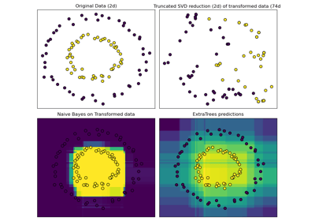

Hashing feature transformation using Totally Random Trees

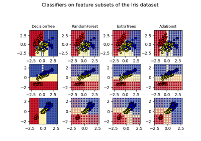

Plot the decision surfaces of ensembles of trees on the iris dataset

© 2007–2025 The scikit-learn developers  
Licensed under the 3-clause BSD License.  
https://scikit-learn.org/1.6/modules/generated/sklearn.ensemble.ExtraTreesClassifier.html